# Tarea 4

# Métodos NO Supervisados con Python

# k-medias

## 1. [40 puntos] En este ejercicio vamos a usar la tabla de datos SpotifyTop2018 40 V2.csv.

### a) Cargue la tabla de datos SpotifyTop2018 40 V2.csv

```
                          danceability  energy  loudness  speechiness  \
Dura                             0.791   0.848    -3.456       0.0506
Plug_Walk                        0.876   0.519    -6.531       0.1430
Silence                          0.520   0.761    -3.093       0.0853
Solo_(feat._Demi_Lovato)         0.737   0.636    -4.546       0.0437
Sin_Pijama                       0.791   0.745    -3.695       0.0464

                          acousticness  instrumentalness  liveness  valence  \
Dura                            0.1830          0.000000     0.409    0.828
Plug_Walk                       0.2020          0.000000     0.108    0.158
Silence                         0.2560          0.000005     0.170    0.286
Solo_(feat._Demi_Lovato)        0.0441          0.000067     0.350    0.565
Sin_Pijama                      0.3540          0.000029     0.104    0.820

                            tempo  duration_ms  time_signature
Dura                       95.000       200480               4
Plug_Walk                  94.981       175230               4
Silence                   141.971       180823               4
Solo_(feat._Demi_Lovato)  105.005       222653               4
Sin_Pijama                 94.014       188560               4
(40, 11)
```

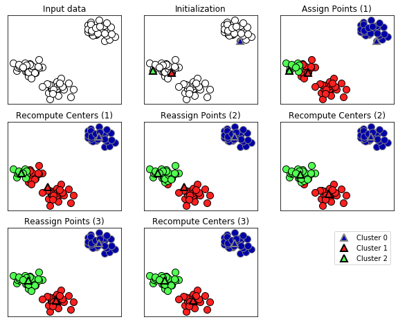

```python
import os
import pandas as pd
pasada = os.getcwd()
os.chdir("C:/Users/rzamoram/Documents/Machine Learning/Métodos NO Supervisados con Python/Clase 1")
os.getcwd()
ejemplo10 = pd.read_csv("SpotifyTop2018_40_V2.csv", decimal = ".", header = 0, index_col = 0)
print(ejemplo10.head())
datos = pd.DataFrame(ejemplo10)
print(datos.shape)

import matplotlib.pyplot as plt
from   sklearn.decomposition import PCA
from   sklearn.datasets import make_blobs
from   sklearn.cluster import KMeans
import numpy as np
from   math import pi

import mglearn
mglearn.plots.plot_kmeans_algorithm() #Prueba de que mglearn funciona

def bar_plot(centros, labels, cluster = None, var = None):
    from math import ceil, floor
    from seaborn import color_palette
    colores = color_palette()
    minimo = floor(centros.min()) if floor(centros.min()) < 0 else 0
    def inside_plot(valores, labels, titulo):
        plt.barh(range(len(valores)), valores, 1/1.5, color = colores)
        plt.xlim(minimo, ceil(centros.max()))
        plt.title(titulo)
    if var is not None:
        centros = np.array([n[[x in var for x in labels]] for n in centros])
        colores = [colores[x % len(colores)] for x, i in enumerate(labels) if i in var]
        labels = labels[[x in var for x in labels]]
    if cluster is None:
        for i in range(centros.shape[0]):
            plt.subplot(1, centros.shape[0], i + 1)
            inside_plot(centros[i].tolist(), labels, ('Cluster ' + str(i)))
            plt.yticks(range(len(labels)), labels) if i == 0 else plt.yticks([])
    else:
        pos = 1
        for i in cluster:
            plt.subplot(1, len(cluster), pos)
            inside_plot(centros[i].tolist(), labels, ('Cluster ' + str(i)))
            plt.yticks(range(len(labels)), labels) if pos == 1 else plt.yticks([])
            pos += 1

def radar_plot(centros, labels):
    from math import pi
    centros = np.array([((n - min(n)) / (max(n) - min(n)) * 100) if
                        max(n) != min(n) else (n/n * 50) for n in centros.T])
    angulos = [n / float(len(labels)) * 2 * pi for n in range(len(labels))]
    angulos += angulos[:1]
    ax = plt.subplot(111, polar = True)
    ax.set_theta_offset(pi / 2)
    ax.set_theta_direction(-1)

    plt.xticks(angulos[:-1], labels)
    ax.set_rlabel_position(0)
    plt.yticks([10, 20, 30, 40, 50, 60, 70, 80, 90, 100],
           ["10%", "20%", "30%", "40%", "50%", "60%", "70%", "80%", "90%", "100%"],
           color = "grey", size = 8)
    plt.ylim(-10, 100)
    for i in range(centros.shape[1]):
        valores = centros[:, i].tolist()
        valores += valores[:1]
        ax.plot(angulos, valores, linewidth = 1, linestyle = 'solid',
                label = 'Cluster ' + str(i))
        ax.fill(angulos, valores, alpha = 0.3)
    plt.legend(loc='upper right', bbox_to_anchor = (0.1, 0.1))
```

### b) Ejecute el m´etodo k−medias para k = 3. Modificaremos los atributos de la clase KMeans(...) como sigue:

```
#Usando  max iter = 1000 y n init = 100.
```

```python
# Ejecuta k-medias con 3 clusters
kmedias = KMeans(n_clusters=3, max_iter=1000, n_init=100)  # Declara la instancia de clase
kmedias.fit(datos)
print(kmedias.predict(datos))
centros = np.array(kmedias.cluster_centers_)
print(centros)
```

```
[0 0 0 1 0 1 1 1 1 1 0 0 1 0 1 0 2 2 0 0 1 1 1 1 1 1 0 0 0 1 0 0 1 1 1 2 1
 1 1 1]
[[ 7.57666667e-01  6.92933333e-01 -5.52653333e+00  1.25120000e-01
   1.57294800e-01  8.95459467e-03  1.81186667e-01  4.75133333e-01
   1.25333533e+02  1.90659467e+05  4.00000000e+00]
 [ 6.85772727e-01  6.51500000e-01 -5.94854545e+00  1.14895455e-01
   1.67878636e-01  6.11742273e-04  1.59418182e-01  4.43077273e-01
   1.18065818e+02  2.28194182e+05  3.90909091e+00]
 [ 7.72000000e-01  5.83333333e-01 -6.69466667e+00  1.49066667e-01
   4.44033333e-01  9.43333333e-06  2.86666667e-01  6.14333333e-01
   1.35634333e+02  1.15221333e+05  4.00000000e+00]]
```

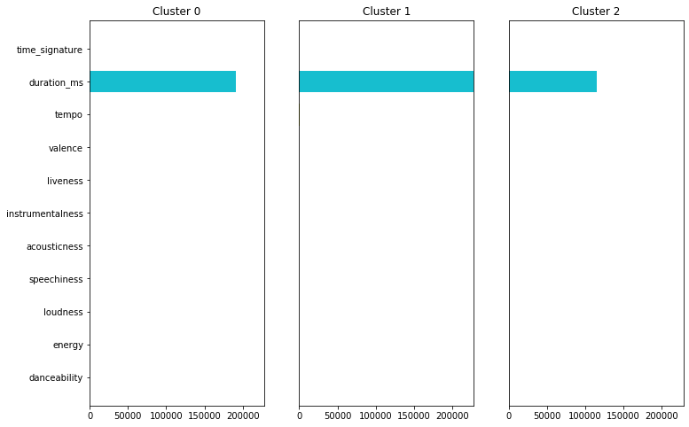

```python
plt.figure(1, figsize = (12, 8))
bar_plot(centros, datos.columns)
```

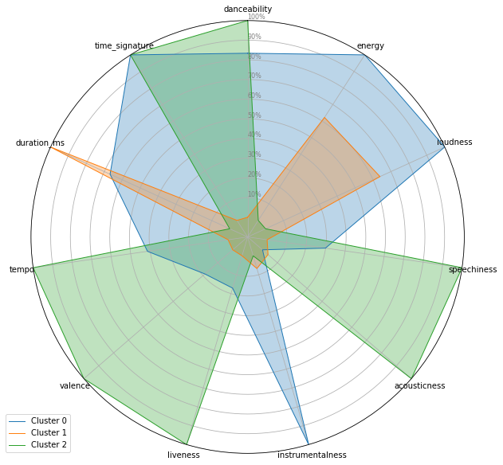

```python
plt.figure(1, figsize = (10, 10))
radar_plot(centros, datos.columns)
```

A diferencia del grafico de barras, el grafico de radar permite analizar los valores estandarizados y de forma visual analizar mejor el grafico. En este caso los clusteres se generan en diferente orden que en el caso del ejercicio de la tarea anterior, pero en esencia la importancia de cada variable y la conformacion de los clusteres es la misma. En este caso se denota que dentro de las 40 canciones mas reproducidas en spotify durante el 2018, estas tienen un agrupacion distintiva segun caracteristicas que las distinguen. Los clusteres se agrupan por canciones con caracteristicas similares, estas caracteristicas son agrupables para determinar canciones. En el primer cluster de canciones (Cluster 0 /Azul) de la tarea anteriorn ahora lo encoentramos como el cluster 2/Verde donde las canciones agrupadas destacan por su liveness, valence, tiempo, time_signature, acousticness, speechiness y danceability; pero muestran poco nivel de duration_ms, instrumentalness, loudness y energy; parece que en este grupo encontramos canciones acusticas probablemente por grupos y que por su conteo en beats puede que sean bailables en ritmos rapidos. El segundo cluster (Cluster 1/Anaranjado) de la semana pasada es ahora el cluester 0/Azul donde se agrupa las canciones que destacan por caracteristicas casi opuestas, tienen un nivel alto de energy, loudness, instrumentalness, e time_signature; a nivel medio-alto estas canciones presentan danceability, speechiness, duration_ms y tempo; no son canciones destacables por su nivel de valence, liveness y acousticness; esto indica que segun instrmuentalness que contiene voces con muchos beats, amplio nivel de enegria y sonoridad amplia. El tercer cluster (Cluster 2/Verde) de la tarea anterior ahora cluster 1/anaranjado solo destaca por su duration_ms, tiene ademas niveles medio-altos en energy y loudness, en todas las demas caracteristicas no destaca teniendo niveles bajos; es decir son canciiones con amplia duracion en milisegundos y nivel medio de energia y sonoridad.

### d) Grafique usando colores sobre las dos primeras componentes del plano principal en el An´alisis en Componentes Principales los cl´usteres obtenidos seg´un k-medias

```
[[ 5.16569563e+03 -2.79335938e+01]
 [ 3.04156953e+04 -3.19517035e+01]
 [ 2.48227028e+04  1.59196406e+01]
 [-1.70073025e+04 -1.44079916e+01]
 [ 1.70856953e+04 -3.08100999e+01]
 [-2.27272978e+04  1.55410955e+01]
 [-6.85430407e+03 -2.50763330e+01]
 [-1.53673049e+04 -2.95806732e+01]
 [-1.17942994e+04  4.81102578e+00]
 [-6.32213046e+04 -2.41684240e+01]
 [ 2.43827025e+04  1.40469759e+01]
 [ 1.12376973e+04 -1.78482586e+01]
 [-5.77543036e+04 -1.78937624e+01]
 [ 1.84987070e+04  4.29519288e+01]
 [-1.57942969e+04  2.05244648e+01]
 [-2.74300015e+02 -7.26639762e-02]
 [ 1.10178700e+05 -9.63548003e+00]
 [ 8.65127008e+04 -1.80874587e+00]
 [ 2.86457041e+04  2.33584883e+01]
 [ 2.10857003e+04  4.50620147e-01]
 [-5.10130449e+03 -2.79044503e+01]
 [-1.16613026e+04 -1.52730503e+01]
 [-3.33542904e+04  6.32287773e+01]
 [-2.18872905e+04  6.13874667e+01]
 [-2.90612886e+04  7.42078636e+01]
 [-2.11543036e+04 -2.07356622e+01]
 [ 8.20869512e+03 -3.14380934e+01]
 [ 1.29870043e+03  2.63122802e+00]
 [ 1.21897068e+04  4.19630942e+01]
 [-2.80673038e+04 -2.16845840e+01]
 [ 6.67269279e+03 -4.59925907e+01]
 [ 1.53577093e+04  5.74204184e+01]
 [-9.20129959e+03  3.34033661e+00]
 [-1.16433025e+04 -1.51487445e+01]
 [-3.29682944e+04  3.81084642e+01]
 [ 7.45817024e+04  8.98287068e+00]
 [-1.22793048e+04 -2.91305863e+01]
 [-2.73133035e+04 -1.97782418e+01]
 [-3.41903056e+04 -3.27780653e+01]
 [-7.66329975e+03  2.17703901e+00]]
(40, 11)
(40, 2)
```

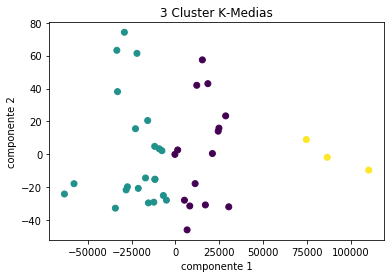

```python
pca = PCA(n_components=2)
componentes = pca.fit_transform(datos)
print(componentes)
print(datos.shape)
print(componentes.shape)
plt.scatter(componentes[:, 0], componentes[:, 1],c=kmedias.predict(datos))
plt.xlabel('componente 1')
plt.ylabel('componente 2')
plt.title('3 Cluster K-Medias')
```

Se denota una division de los clusteres bastante amplia, por lo que ya se puede considerar un clustering optimo, al no verse un traslapa de datos importante.

### e) Usando 50 ejecuciones del m´etodo k−medias grafique el “Codo de Jambu” para este ejemplo.

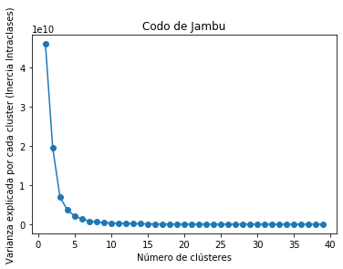

```python
###Nc = range(1, 20)
Nc = range(1, 40)
kmediasList = [KMeans(n_clusters=i) for i in Nc]
varianza = [kmediasList[i].fit(datos).inertia_ for i in range(len(kmediasList))]
plt.plot(Nc,varianza,'o-')
plt.xlabel('Número de clústeres')
plt.ylabel('Varianza explicada por cada cluster (Inercia Intraclases)')
plt.title('Codo de Jambu')
```

Inicialmente se procura realizar con 50 ejecuciones pero por falta de n samples se requiere disminuir a un maximo (>= n_clusters=41) por lo que se toman 40 ejecuciones. A pesar de que es dificil identificar visulamente el punto de quiebre esta bastante presente es decir, 3 clusteres parece el quiebre mas grande por ello se aplica un codo de jambu adcional con menos ejecuciones para identificar mejor.

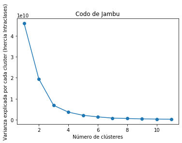

```python
Nc = range(1, 12)
kmediasList = [KMeans(n_clusters=i) for i in Nc]
varianza = [kmediasList[i].fit(datos).inertia_ for i in range(len(kmediasList))]
plt.plot(Nc,varianza,'o-')
plt.xlabel('Número de clústeres')
plt.ylabel('Varianza explicada por cada cluster (Inercia Intraclases)')
plt.title('Codo de Jambu')
```

Cabe destacar que ademas para generar un analisis de clusteres optimo suele ser mejor elegir un numero bajo de k. En este caso observando con menos ejecuciones. Resulta mas optimo identificar el punto de quibre, en este caso, el quiebre mas importante se denota en tres, aunque tambien hay un quibre razonable en 2, la grafica de jambu en ambos casos parece estabilizarse, es decir, hay un punto donde parece ya no importar si se agrega o no mas clusteres, parece que en ambas graficas pasa entre la 4 y 7, ya despues de esto la funcion se estabiliza por completo visualmente. Viendo ambas graficas parece que especialmente despues de la 7 la linea de para determinar la inercia segun clusters se estabiliza por completo.

# 2. [40 puntos] En este ejercicio vamos a realizar k-medias para la tabla SAheart.csv

```python
import os
import pandas as pd
pasada = os.getcwd()
os.chdir("C:/Users/rzamoram/Documents/Machine Learning/Métodos NO Supervisados con Python/Clase 3")
os.getcwd()
ejemplo10 = pd.read_csv("SAheart.csv", delimiter = ';', decimal = ".", header = 0, index_col = 0)
print(ejemplo10.head())
datos = pd.DataFrame(ejemplo10)
```

```
     tobacco   ldl  adiposity  famhist  typea  obesity  alcohol  age chd
sbp
160    12.00  5.73      23.11  Present     49    25.30    97.20   52  Si
144     0.01  4.41      28.61   Absent     55    28.87     2.06   63  Si
118     0.08  3.48      32.28  Present     52    29.14     3.81   46  No
170     7.50  6.41      38.03  Present     51    31.99    24.26   58  Si
134    13.60  3.50      27.78  Present     60    25.99    57.34   49  Si
```

```python
datos_dummy = pd.get_dummies(datos)
print(datos_dummy.head())
print(datos_dummy.dtypes)
datosnum = datos_dummy.iloc[:,0:7] ##Usando solo numericas del archivo de datos, se eliminan las categoricas
print(datosnum.head())
```

```
     tobacco   ldl  adiposity  typea  obesity  alcohol  age  famhist_Absent  \
sbp
160    12.00  5.73      23.11     49    25.30    97.20   52               0
144     0.01  4.41      28.61     55    28.87     2.06   63               1
118     0.08  3.48      32.28     52    29.14     3.81   46               0
170     7.50  6.41      38.03     51    31.99    24.26   58               0
134    13.60  3.50      27.78     60    25.99    57.34   49               0

     famhist_Present  chd_No  chd_Si
sbp
160                1       0       1
144                0       0       1
118                1       1       0
170                1       0       1
134                1       0       1
tobacco            float64
ldl                float64
adiposity          float64
typea                int64
obesity            float64
alcohol            float64
age                  int64
famhist_Absent       uint8
famhist_Present      uint8
chd_No               uint8
chd_Si               uint8
dtype: object
     tobacco   ldl  adiposity  typea  obesity  alcohol  age
sbp
160    12.00  5.73      23.11     49    25.30    97.20   52
144     0.01  4.41      28.61     55    28.87     2.06   63
118     0.08  3.48      32.28     52    29.14     3.81   46
170     7.50  6.41      38.03     51    31.99    24.26   58
134    13.60  3.50      27.78     60    25.99    57.34   49
```

```python
kmedias = KMeans(n_clusters=3, max_iter=2000, n_init=150)  # Declara la instancia de clase
kmedias.fit(datosnum)
print(kmedias.predict(datosnum))
centros = np.array(kmedias.cluster_centers_)
print(centros)
```

```
[2 1 1 1 2 1 0 1 0 1 2 0 0 0 1 1 1 1 2 1 0 1 1 1 1 1 1 1 1 1 1 1 1 1 1 2 0
 1 0 1 1 0 0 1 0 1 1 0 0 0 1 1 1 2 2 2 0 0 0 1 0 1 1 0 0 2 0 0 0 0 0 0 2 0
 0 0 1 1 1 2 1 1 1 1 0 1 1 0 0 1 0 1 0 1 1 1 0 1 1 0 1 0 1 0 0 2 1 1 1 0 0
 1 0 1 2 1 0 1 1 0 1 0 0 1 1 1 0 1 1 1 1 2 0 1 2 1 0 0 0 1 1 0 0 1 1 0 0 1
 0 1 1 1 0 0 2 2 0 2 0 1 0 1 0 0 0 1 1 1 0 1 1 0 1 1 1 1 0 0 0 1 1 1 1 0 2
 0 1 1 1 1 1 1 0 0 0 0 0 1 1 0 2 2 0 1 1 1 0 1 1 1 1 1 1 1 0 1 1 0 0 1 0 1
 1 1 1 1 0 1 1 1 2 1 1 0 2 1 1 1 0 0 1 1 2 1 1 1 1 1 1 1 2 0 1 1 2 1 1 1 1
 2 0 0 1 0 1 0 0 1 0 1 1 1 0 1 1 1 1 1 0 0 0 2 1 0 2 0 0 0 0 1 0 0 0 1 0 1
 0 0 2 1 1 0 1 1 0 1 1 1 2 2 1 2 1 1 2 2 0 0 1 1 2 0 1 1 1 0 1 0 0 1 0 1 1
 1 1 1 2 1 0 2 1 1 2 2 2 2 1 1 1 1 1 0 1 1 1 1 2 1 1 0 1 0 2 2 1 2 0 0 0 1
 1 2 0 1 2 1 2 1 2 1 1 2 0 0 2 1 1 1 0 2 0 1 1 1 1 0 1 2 2 1 1 1 1 1 1 1 1
 1 1 0 1 1 1 1 1 2 2 1 1 1 2 1 2 1 1 0 2 2 0 0 0 0 0 0 0 0 0 0 0 0 0 0 2 0
 0 0 0 0 0 2 0 0 2 1 1 2 1 1 1 1 1 1]
[[ 1.15303226  3.86825806 18.56483871 54.1483871  24.13909677  7.07587097
  26.32258065]
 [ 4.70128099  5.41780992 29.4172314  52.3553719  27.16355372 10.00326446
  52.93801653]
 [ 5.58830769  4.29753846 26.79061538 53.4        26.41907692 67.03015385
  44.46153846]]
```

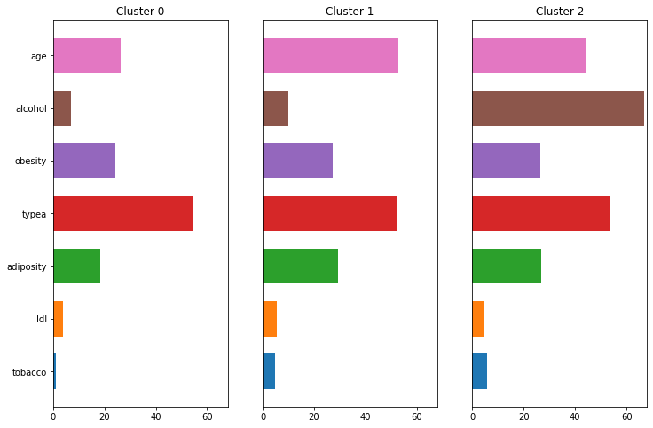

```python
plt.figure(1, figsize = (12, 8))
bar_plot(centros, datosnum.columns)
```

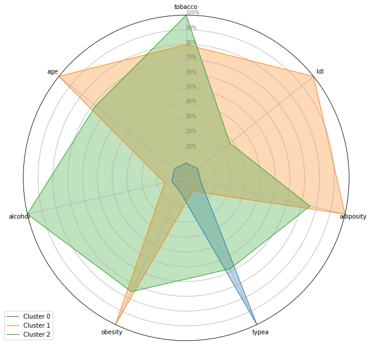

```python
plt.figure(1, figsize = (10, 10))
radar_plot(centros, datosnum.columns)
```

[output not shown]

[output cut: 409 more lines]

```
 [ 7.30342533e+01  4.01092913e+00]
 [ 4.92125875e+00  2.66514216e+01]
 [-1.90604480e+01  2.71269021e+01]
 [ 2.58331688e+01  3.19822026e+00]
 [-1.56203426e+01 -1.67405365e+01]
 [-9.01110455e+00  2.33164030e+00]
 [ 2.83729384e+01  1.74722102e+01]
 [-1.25588178e+01 -2.05840246e+01]
 [-1.49591474e+01 -1.67903718e+01]
 [ 2.99719543e+00 -1.09464273e+01]
 [ 9.96955012e+00 -6.69245555e+00]
 [ 7.10625932e+00  1.85255522e+00]
 [-1.63705900e+01 -5.19530892e+00]]
(462, 7)
(462, 2)
```

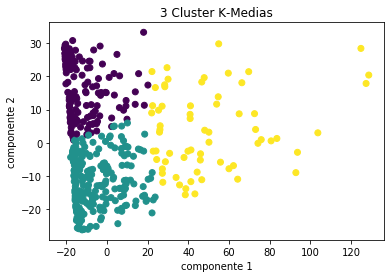

```python
pca = PCA(n_components=2)
componentes = pca.fit_transform(datosnum)
print(componentes)
print(datosnum.shape)
print(componentes.shape)
plt.scatter(componentes[:, 0], componentes[:, 1],c=kmedias.predict(datosnum))
plt.xlabel('componente 1')
plt.ylabel('componente 2')
plt.title('3 Cluster K-Medias')
```

Se denota una division de los clusteres poco amplia, por lo que ya se puede considerar un clustering semi-optimo, al no verse cierto traslape de datos

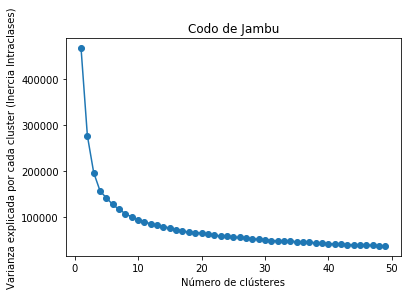

```python
Nc = range(1, 50)
kmediasList = [KMeans(n_clusters=i) for i in Nc]
varianza = [kmediasList[i].fit(datosnum).inertia_ for i in range(len(kmediasList))]
plt.plot(Nc,varianza,'o-')
plt.xlabel('Número de clústeres')
plt.ylabel('Varianza explicada por cada cluster (Inercia Intraclases)')
plt.title('Codo de Jambu')
```

En esencia resulta aqui con 50 ejecuciones analizar puntos de quiebre y estabilizacion de la inercia, se procura realizar con 50 ejecuciones. A pesar de que es dificil identificar visulamente el punto de quiebre no esta bastante presente es decir, 4 clusteres parece el quiebre mas grande por ello se aplica un codo de jambu adcional con menos ejecuciones para identificar mejor, para validar

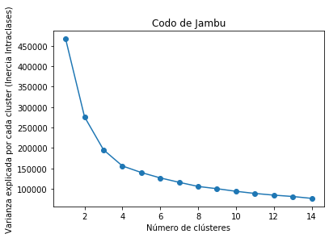

```python
Nc = range(1, 15)
kmediasList = [KMeans(n_clusters=i) for i in Nc]
varianza = [kmediasList[i].fit(datosnum).inertia_ for i in range(len(kmediasList))]
plt.plot(Nc,varianza,'o-')
plt.xlabel('Número de clústeres')
plt.ylabel('Varianza explicada por cada cluster (Inercia Intraclases)')
plt.title('Codo de Jambu')
```

De nuevo debe mencionarse que para generar un analisis de clusteres optimo suele ser mejor elegir un numero bajo de k. En este caso observando con menos ejecuciones. Resulta mas optimo identificar el punto de quibre, en este caso, el quiebre mas importante se denota en tres, aunque tambien y segun lo indicado anteriormenete, parece que en 4 se estabiliza mas la grafica de Jambu, parece en este caso que el ejericio tal vez mejore con 4 clusteres. 2 clusteres tambien parece factible, es decir, los quiebres son en realidad un punto de vista experto, por lo que cabe analizar distintas posibilidades.

## b) Repita los ejercicios anteriores pero esta vez incluya las variables categ´oricas usando c´odigos disyuntivos completos. ¿Son mejores los resultados?

```python
def recodificar(col, nuevo_codigo):
  col_cod = pd.Series(col, copy=True)
  for llave, valor in nuevo_codigo.items():
    col_cod.replace(llave, valor, inplace=True)
  return col_cod
```

```python
datos["famhist"] = recodificar(datos["famhist"], {'Present':1,'Absent':2})
datos["chd"] = recodificar(datos["chd"], {'No':0,'Si':1})
print(datos.head())
print(datos.dtypes)
# Conviertiendo la variables en Dummy
datos_dummy = pd.get_dummies(datos)
print(datos_dummy.head())
print(datos_dummy.dtypes)
```

```
     tobacco   ldl  adiposity  famhist  typea  obesity  alcohol  age  chd
sbp
160    12.00  5.73      23.11        1     49    25.30    97.20   52    1
144     0.01  4.41      28.61        2     55    28.87     2.06   63    1
118     0.08  3.48      32.28        1     52    29.14     3.81   46    0
170     7.50  6.41      38.03        1     51    31.99    24.26   58    1
134    13.60  3.50      27.78        1     60    25.99    57.34   49    1
tobacco      float64
ldl          float64
adiposity    float64
famhist        int64
typea          int64
obesity      float64
alcohol      float64
age            int64
chd            int64
dtype: object
     tobacco   ldl  adiposity  famhist  typea  obesity  alcohol  age  chd
sbp
160    12.00  5.73      23.11        1     49    25.30    97.20   52    1
144     0.01  4.41      28.61        2     55    28.87     2.06   63    1
118     0.08  3.48      32.28        1     52    29.14     3.81   46    0
170     7.50  6.41      38.03        1     51    31.99    24.26   58    1
134    13.60  3.50      27.78        1     60    25.99    57.34   49    1
tobacco      float64
ldl          float64
adiposity    float64
famhist        int64
typea          int64
obesity      float64
alcohol      float64
age            int64
chd            int64
dtype: object
```

```python
kmedias = KMeans(n_clusters=3, max_iter=2000, n_init=150)  # Declara la instancia de clase
kmedias.fit(datos_dummy)
print(kmedias.predict(datos_dummy))
centros = np.array(kmedias.cluster_centers_)
print(centros)
```

```
[2 1 1 1 2 1 0 1 0 1 2 0 0 0 1 1 1 1 2 1 0 1 1 1 1 1 1 1 1 1 1 1 1 1 1 2 0
 1 0 1 1 0 0 1 0 1 1 0 0 0 1 1 1 2 2 2 0 0 0 1 0 1 1 0 0 2 0 0 0 0 0 0 2 0
 0 0 1 1 1 2 1 1 1 1 0 1 1 0 0 1 0 1 0 1 1 1 0 1 1 0 1 0 1 0 0 2 1 1 1 0 0
 1 0 1 2 1 0 1 1 0 1 0 0 1 1 1 0 1 1 1 1 2 0 1 2 1 0 0 0 1 1 0 0 1 1 0 0 1
 0 1 1 1 0 0 2 2 0 2 0 1 0 1 0 0 0 1 1 1 0 1 1 0 1 1 1 1 0 0 0 1 1 1 1 0 2
 0 1 1 1 1 1 1 0 0 0 0 0 1 1 0 2 2 0 1 1 1 0 1 1 1 1 1 1 1 0 1 1 0 0 1 0 1
 1 1 1 1 0 1 1 1 2 1 1 0 2 1 1 1 0 0 1 1 2 1 1 1 1 1 1 1 2 0 1 1 2 1 1 1 1
 2 0 0 1 0 1 0 0 1 0 1 1 1 0 1 1 1 1 1 0 0 0 2 1 0 2 0 0 0 0 1 0 0 0 1 0 1
 0 0 2 1 1 0 1 1 0 1 1 1 2 2 1 2 1 1 2 2 0 0 1 1 2 0 1 1 1 0 1 0 0 1 0 1 1
 1 1 1 2 1 0 2 1 1 2 2 2 2 1 1 1 1 1 0 1 1 1 1 2 1 1 0 1 0 2 2 1 2 0 0 0 1
 1 2 0 1 2 1 2 1 2 1 1 2 0 0 2 1 1 1 0 2 0 1 1 1 1 0 1 2 2 1 1 1 1 1 1 1 1
 1 1 0 1 1 1 1 1 2 2 1 1 1 2 1 2 1 1 0 2 2 0 0 0 0 0 0 0 0 0 0 0 0 0 0 2 0
 0 0 0 0 0 2 0 0 2 1 1 2 1 1 1 1 1 1]
[[ 1.15303226  3.86825806 18.56483871  1.73548387 54.1483871  24.13909677
   7.07587097 26.32258065  0.12903226]
 [ 4.70128099  5.41780992 29.4172314   1.50413223 52.3553719  27.16355372
  10.00326446 52.93801653  0.47520661]
 [ 5.58830769  4.29753846 26.79061538  1.52307692 53.4        26.41907692
  67.03015385 44.46153846  0.38461538]]
```

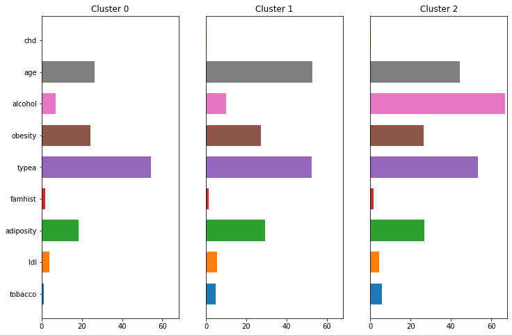

```python
plt.figure(1, figsize = (12, 8))
bar_plot(centros, datos_dummy.columns)
```

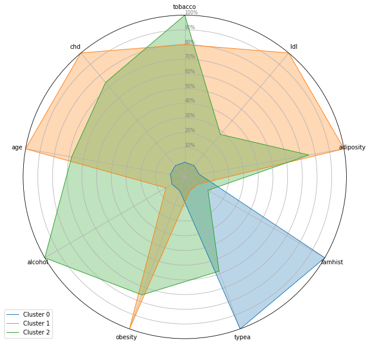

```python
plt.figure(1, figsize = (10, 10))
radar_plot(centros, datos_dummy.columns)
```

[output not shown]

[output cut: 409 more lines]

```
 [ 7.30362336e+01  4.00330248e+00]
 [ 4.91922929e+00  2.66555864e+01]
 [-1.90623894e+01  2.71294304e+01]
 [ 2.58335689e+01  3.19853340e+00]
 [-1.56176515e+01 -1.67500791e+01]
 [-9.01075461e+00  2.32633316e+00]
 [ 2.83727539e+01  1.74687331e+01]
 [-1.25577554e+01 -2.05836161e+01]
 [-1.49601018e+01 -1.67839732e+01]
 [ 2.99777740e+00 -1.09494704e+01]
 [ 9.96817829e+00 -6.68376255e+00]
 [ 7.10479975e+00  1.85868952e+00]
 [-1.63680551e+01 -5.20767817e+00]]
(462, 9)
(462, 2)
```

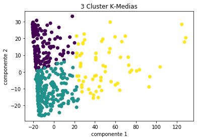

```python
pca = PCA(n_components=2)
componentes = pca.fit_transform(datos_dummy)
print(componentes)
print(datos_dummy.shape)
print(componentes.shape)
plt.scatter(componentes[:, 0], componentes[:, 1],c=kmedias.predict(datos_dummy))
plt.xlabel('componente 1')
plt.ylabel('componente 2')
plt.title('3 Cluster K-Medias')
```

Se denota nuevamente una division de los clusteres poco amplia, por lo que ya se puede considerar un clustering semi-optimo, al no verse cierto traslape de datos

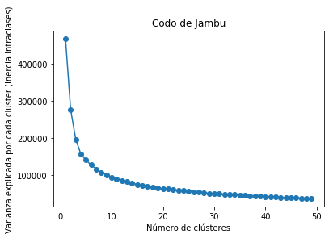

```python
Nc = range(1, 50)
kmediasList = [KMeans(n_clusters=i) for i in Nc]
varianza = [kmediasList[i].fit(datos_dummy).inertia_ for i in range(len(kmediasList))]
plt.plot(Nc,varianza,'o-')
plt.xlabel('Número de clústeres')
plt.ylabel('Varianza explicada por cada cluster (Inercia Intraclases)')
plt.title('Codo de Jambu')
```

Nuevamente con 50 ejecuciones analizar puntos de quiebre y estabilizacion de la inercia, se procura realizar con 50 ejecuciones. A pesar de que es dificil identificar visulamente el punto de quiebre no esta bastante presente es decir, nuevamente 4 clusteres parece el quiebre mas grande por ello se aplica un codo de jambu adcional con menos ejecuciones para identificar mejor, para validar

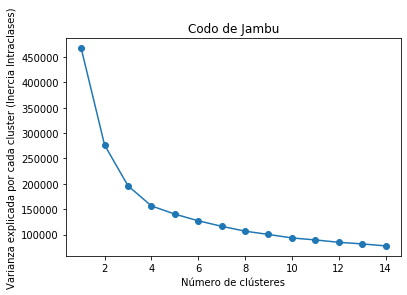

```python
Nc = range(1, 15)
kmediasList = [KMeans(n_clusters=i) for i in Nc]
varianza = [kmediasList[i].fit(datos_dummy).inertia_ for i in range(len(kmediasList))]
plt.plot(Nc,varianza,'o-')
plt.xlabel('Número de clústeres')
plt.ylabel('Varianza explicada por cada cluster (Inercia Intraclases)')
plt.title('Codo de Jambu')
```

En este caso observando con menos ejecuciones. Resulta mas optimo identificar el punto de quibre, en este caso, el quiebre mas importante se denota en tres nuevamente aunque esta vez mejor, aunque tambien y segun lo indicado anteriormenete, parece que en 4 se estabiliza de nuevo mas la grafica de Jambu, parece en este caso que el ejericio tal vez mejore con 4 clusteres. Los quiebres son un punto de vista experto, por lo que cabe analizar distintas posibilidades.

La gran diferencia es que en el primer ejercicio se toman unicamente las variables numericas y en el siguiente se incluyen las variables categoricas que asi mismo son parte crucial del problema ya que indican si el paciente presenta historia familiar de enferemdades cardiacas (famhist) y si posee enferemdad coronaria del corazon (chd). Dado que se incluyen estas dos variables tan vitales en el estudio del problema me parece mejor incluirlas ya que dan y corroboran informacion vital acerca del paciente, las variables numericas indican caracteristicas del paciente pero sin mostrar la variable de resultado. Cabe destacar que los resultados en ambos ejericios son simlares y no parecen verse significativamente afectados por la inclusion de estas dos ultimas variables. Pero la interpretacion cambia significativamente ya que la interpretacion de los clusters varia. Aqui se permite entrever la diferencia en la salud del corazon de cada paciente, mostrando que en el cluster 1 y 2 existe problemas y en el cluster 0 existe una baja afeccion del corazon. Las variables categoricas mejoran en ese sentido significativamente la interpretacion del problema. En el caso del ejericio anterior sin estas variables cataegoricas solo se puede presumir casi que por razones obvias cual es el cluster mas sano ya que no estaba la variable categorica chd que indica si la persona en estudio tiene problemas del corazon.